# Development Analysis *(WIP)*

Josiah Parry

April 25, 2016

The purpose of this document is to compare the responses to the development portion of the Newfound Lake PPGIS Study. This analysis will explore the difference between Non-Member and Member responses.

First I begin by creating two different data frames, one with members and the other with non-members.

```r
member <- dev %>% filter(NLRA_Member == "Yes")
nonmmbr <- dev %>% filter(NLRA_Member == "No")
```

I first wanted to check to see if there were any significant differences in the genders of our respondents.

```r
p1 <- member %>% filter(Gender == "Male") %>% summarize(n = n())
p2 <-nonmmbr %>% filter(Gender == "Male") %>% summarize(n = n())

prop.test(x = c(p1$n, p2$n), n = c(dim(member)[1], dim(nonmmbr)[1]), correct = FALSE)
```

```
##
##  2-sample test for equality of proportions without continuity
##  correction
##
## data:  c(p1$n, p2$n) out of c(dim(member)[1], dim(nonmmbr)[1])
## X-squared = 4.7781, df = 1, p-value = 0.02882
## alternative hypothesis: two.sided
## 95 percent confidence interval:
##  0.02915756 0.48620887
## sample estimates:
##    prop 1    prop 2
## 0.7021277 0.4444444
```

Responses by gender proportion significantly different `(p = 0.03)`. Members are 70% Male, 30% Female. Non-members are 45% male, 55% female. This is just good to note.

### Housing

Two sample t-tests were conducted to test for similarity in responses.

```r
#High Density Apartments
t.test(member$highdensity_apartments, nonmmbr$highdensity_apartments)

#High Density Single Family Homes
t.test(member$highdensity_singlefamily, nonmmbr$highdensity_singlefamily)

#Rural Density > 10 Acres
t.test(member$ruraldensity_lessthan10, nonmmbr$ruraldensity_lessthan10)

#Rural Density < 10 Acres
t.test(member$ruraldensity_10plus, nonmmbr$ruraldensity_10plus)

#Workforce Housing
t.test(member$workforce_housing, nonmmbr$workforce_housing)

#Accessory Housing
t.test(member$accessory_apartments, nonmmbr$accessory_apartments)
```

[output not shown]

### Non - housing developement

Two sample t-tests were conducted to test for similarity in responses.

```r
#Recreation
t.test(member$recreation, nonmmbr$recreation)

#Small Business
t.test(member$small_business, nonmmbr$small_business)

#Commercial Business
t.test(member$commercial_business, nonmmbr$commercial_business)
```

[output not shown]

#### Significant Differences (Members vs. Non-Members)

##### High Density Apartments

28.6% of members indicated an interest in developing high density apartments `(p=0.000)`. Whereas non-members did not once indicate an interest in developing apartments.

##### High Density Single Family Homes

43% of members indicated an interest in developing high density single family homes `(p=0.005)`. Only 12.5% of non-members indicated interest in developing high density single family homes.

#### commercial business

31% of members indicated interest in developing commercial business, whereas only 8% of non-members indicated this interest `(p=0.017)`.

### Visualizing These Differences

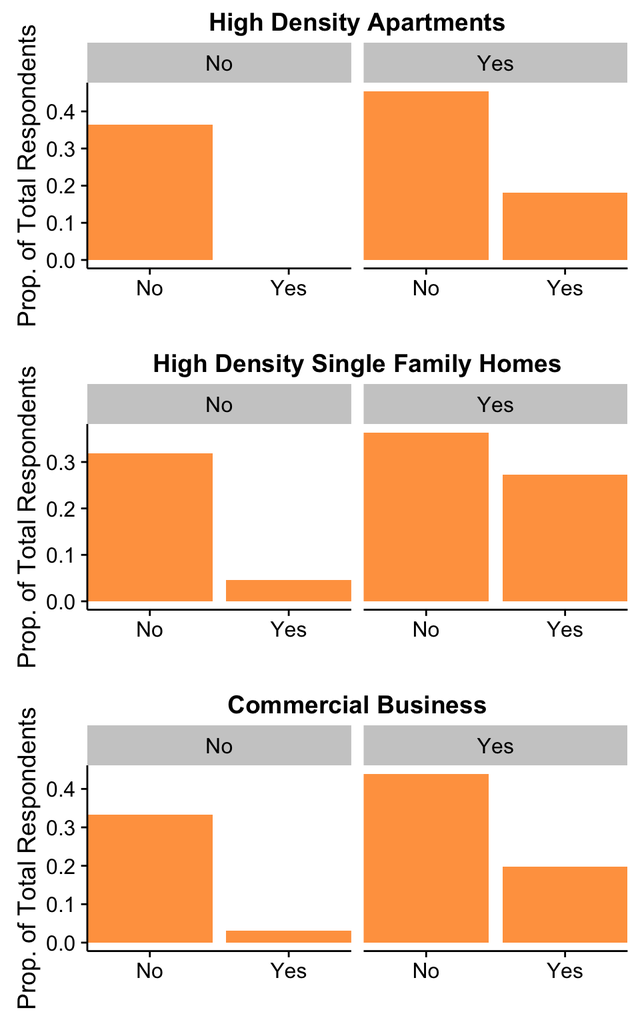